# R Notebook

```r
library(dplyr)
library(ggplot2)
library(stringr)
library(tidytext)
library(gsubfn)
library(tidyr)
```

Read in the data set

```r
injuries <- read.csv("injuries_players2021-11-15.csv")
```

```r
head(injuries)
```

|  | X | name | full_team | team | year | games_in_season | num_games_missing | num_games_injured | injury_types | earliest_injury | latest_injury | position_id | NFL_draft_year | NFL_draft_round | NFL_draft_rank | height_inches | weight_pounds | birthdate | forty_yd | three_cone | bench | broad_jump | combine_height | combine_weight | shuttle | vertical | game_starter |
| --- | --- | --- | --- | --- | --- | --- | --- | --- | --- | --- | --- | --- | --- | --- | --- | --- | --- | --- | --- | --- | --- | --- | --- | --- | --- | --- | --- |
| 1 | 18 | Michael Adams | Arizona Cardinals | crd | 2009 | 18 | 0 | 3 | hamstring | 8 | 14 | DEF | NA | NA | NA | 68 | 178 | 1985-06-17 | NA | NA | NA | NA | NA | NA | NA | NA | 0 |
| 2 | 19 | Jason Banks | Arizona Cardinals | crd | 2009 | 18 | 2 | 2 | ankle | 17 | 18 | DEF | NA | NA | NA | 77 | 300 | 1985-05-08 | NA | NA | NA | NA | NA | NA | NA | NA | 0 |
| 3 | 36 | Bertrand Berry | Arizona Cardinals | crd | 2009 | 18 | 0 | 1 | illness | 13 | 13 | DEF | 1997 | 3 | 86 | 75 | 254 | 1975-08-15 | NA | NA | NA | NA | NA | NA | NA | NA | 0 |
| 4 | 51 | Anquan Boldin | Arizona Cardinals | crd | 2009 | 18 | 3 | 8 | hamstring ankle ankle/knee | 1 | 18 | WR | 2003 | 2 | 54 | 73 | 220 | 1980-10-03 | 4.72 | 7.35 | 0 | 114 | 73 | 216 | 4.33 | 33.5 | 1 |
| 5 | 69 | Alan Branch | Arizona Cardinals | crd | 2009 | 18 | 0 | 1 | ankle | 13 | 13 | DEF | 2007 | 2 | 33 | 78 | 350 | 1984-12-29 | 5.07 | 0.00 | 33 | 107 | 78 | 324 | 0.00 | 27.5 | 0 |
| 6 | 86 | Steve Breaston | Arizona Cardinals | crd | 2009 | 18 | 1 | 11 | knee | 1 | 11 | WR | 2007 | 5 | 142 | 73 | 175 | 1983-08-20 | 4.46 | 6.90 | 0 | 124 | 72 | 193 | 4.29 | 33.0 | 1 |

```r
dim(injuries)
```

```
[1] 17362    27
```

```r
injuries <- injuries %>% mutate(injury_types = tolower(injury_types))
```

```r
# Replace any "/" with " " ?
injuries$injury_types <- gsub("/", " ", injuries$injury_types)
```

Body part vectors

```r
Head <- c("concussion", "head", "neck", "eye", "ear", "chin", "migranes", "migrane", "jaw", "nose", "tooth", "stinger", "faciallaceration", "eyelid", "facial", "mouth", "nose", "throat", "seizure")

Shoulder <- c("shoulder", "clavicle", "collarbone", "leftshoulder", "rightshoulder", "jointshoulder", "scapula", "sternoclavicular")

UpperTorso <- c("rib", "back", "pectoral", "pec", "chest", "oblique", "lumbar", "core", "spine", "trapezius", "kidney", "lung", "heart", "abdomen", "abdominal", "solarplexus", "spleen", "hernia", "arrhythmia", "liver", "stomach", "appendix")

LowerTorso <- c("glute", "buttocks", "hip", "righthip", "pelvis", "tailbone")


Arm <- c("arm", "rightupperarm", "forearm", "bicep", "biceps", "elbow", "rightelbow", "tricep", "triceps")

Hand <- c("hand", "righthand", "thumb", "rightthumb", "finger", "rightfinger", "wrist", "rightwrist")

Leg <- c("hamstring", "righthamstring", "knee", "rightknee", "acl", "mcl", "meniscus", "bothknees", "thigh", "rightthigh", "calf", "rightcalf", "quadricep", "rightquadricep", "quad", "groin", "rightgroin", "lowerleg", "tibia", "fibula", "shin", "rightshin", "adductor", "contusion")

Foot <- c("foot", "rightfoot", "ankle", "achilles", "toe", "toes", "heel")
```

Function to count broad body part injuries

```r
# Bodypart input must be a string
broad <- function(bodylist, bodypart) {

  pasted <- paste(bodylist, collapse = "|")
  broad_injury <- gsub(pasted, bodypart, injuries$injury_types)
  str_count(broad_injury, pattern = bodypart)

  }
```

Calculating broad injury counts

```r
# Head
head_counts <- broad(Head, "head")

# Shoulder
shoulder_counts <- broad(Shoulder, "shoulder")

# Upper Torso
uppertorso_counts <- broad(UpperTorso, "uppertorso")

# Lower Torso
lowertorso_counts <- broad(LowerTorso, "lowertorso")

# Arm
arm_counts <- broad(Arm, "arm")

# Hand
hand_counts <- broad(Hand, "hand")

# Leg
leg_counts <- broad(Leg, "leg")

# Foot
foot_counts <- broad(Foot, "foot")
```

```r
injuries
```

| X | name | full_team | team | year | games_in_season | num_games_missing | num_games_injured | injury_types | earliest_injury | latest_injury | position_id | NFL_draft_year | NFL_draft_round | NFL_draft_rank | height_inches | weight_pounds | birthdate | forty_yd | three_cone | bench | broad_jump | combine_height | combine_weight | shuttle | vertical | game_starter |
| --- | --- | --- | --- | --- | --- | --- | --- | --- | --- | --- | --- | --- | --- | --- | --- | --- | --- | --- | --- | --- | --- | --- | --- | --- | --- | --- |
| 18 | Michael Adams | Arizona Cardinals | crd | 2009 | 18 | 0 | 3 | hamstring | 8 | 14 | DEF | NA | NA | NA | 68 | 178 | 1985-06-17 | NA | NA | NA | NA | NA | NA | NA | NA | 0 |
| 19 | Jason Banks | Arizona Cardinals | crd | 2009 | 18 | 2 | 2 | ankle | 17 | 18 | DEF | NA | NA | NA | 77 | 300 | 1985-05-08 | NA | NA | NA | NA | NA | NA | NA | NA | 0 |
| 36 | Bertrand Berry | Arizona Cardinals | crd | 2009 | 18 | 0 | 1 | illness | 13 | 13 | DEF | 1997 | 3 | 86 | 75 | 254 | 1975-08-15 | NA | NA | NA | NA | NA | NA | NA | NA | 0 |
| 51 | Anquan Boldin | Arizona Cardinals | crd | 2009 | 18 | 3 | 8 | hamstring ankle ankle knee | 1 | 18 | WR | 2003 | 2 | 54 | 73 | 220 | 1980-10-03 | 4.72 | 7.35 | 0 | 114 | 73 | 216 | 4.33 | 33.5 | 1 |
| 69 | Alan Branch | Arizona Cardinals | crd | 2009 | 18 | 0 | 1 | ankle | 13 | 13 | DEF | 2007 | 2 | 33 | 78 | 350 | 1984-12-29 | 5.07 | 0.00 | 33 | 107 | 78 | 324 | 0.00 | 27.5 | 0 |
| 86 | Steve Breaston | Arizona Cardinals | crd | 2009 | 18 | 1 | 11 | knee | 1 | 11 | WR | 2007 | 5 | 142 | 73 | 175 | 1983-08-20 | 4.46 | 6.90 | 0 | 124 | 72 | 193 | 4.29 | 33.0 | 1 |
| 87 | Cody Brown | Arizona Cardinals | crd | 2009 | 18 | 18 | 18 | wrist | 1 | 18 | NA | NA | NA | NA | NA | NA | NA | NA | NA | NA | NA | NA | NA | NA | NA | NA |
| 105 | Levi Brown | Arizona Cardinals | crd | 2009 | 18 | 0 | 2 | ankle knee | 3 | 6 | OL | 2007 | 1 | 5 | 78 | 323 | 1984-03-16 | 5.40 | 7.87 | 31 | 97 | 77 | 323 | 4.89 | 25.5 | 1 |
| 123 | Calais Campbell | Arizona Cardinals | crd | 2009 | 18 | 0 | 2 | thumb | 17 | 18 | DEF | 2008 | 2 | 50 | 80 | 300 | 1986-09-01 | 5.04 | 7.45 | 16 | 111 | 80 | 290 | 4.69 | 29.5 | 1 |
| 141 | Karlos Dansby | Arizona Cardinals | crd | 2009 | 18 | 0 | 3 | shoulder | 10 | 12 | DEF | 2004 | 2 | 33 | 76 | 250 | 1981-11-03 | 4.58 | 0.00 | 0 | 0 | 75 | 251 | 0.00 | 0.0 | 1 |

[output cut: 990 more lines]

Adding body part columns to the orginal injury data frame

```r
injuries <- injuries %>%
  mutate(head = head_counts) %>%
  mutate(shoulder = shoulder_counts) %>%
  mutate(upper_torso = uppertorso_counts) %>%
  mutate(lower_torso = lowertorso_counts) %>%
  mutate(arm = arm_counts) %>%
  mutate(hand = hand_counts) %>%
  mutate(leg = leg_counts) %>%
  mutate(foot = foot_counts)


injuries
```

| X | name | full_team | team | year | games_in_season | num_games_missing | num_games_injured | injury_types | earliest_injury | latest_injury | position_id | NFL_draft_year | NFL_draft_round | NFL_draft_rank | height_inches | weight_pounds | birthdate | forty_yd | three_cone | bench | broad_jump | combine_height | combine_weight | shuttle | vertical | game_starter | head | shoulder | upper_torso | … |
| --- | --- | --- | --- | --- | --- | --- | --- | --- | --- | --- | --- | --- | --- | --- | --- | --- | --- | --- | --- | --- | --- | --- | --- | --- | --- | --- | --- | --- | --- | --- |
| 18 | Michael Adams | Arizona Cardinals | crd | 2009 | 18 | 0 | 3 | hamstring | 8 | 14 | DEF | NA | NA | NA | 68 | 178 | 1985-06-17 | NA | NA | NA | NA | NA | NA | NA | NA | 0 | 0 | 0 | 0 | … |
| 19 | Jason Banks | Arizona Cardinals | crd | 2009 | 18 | 2 | 2 | ankle | 17 | 18 | DEF | NA | NA | NA | 77 | 300 | 1985-05-08 | NA | NA | NA | NA | NA | NA | NA | NA | 0 | 0 | 0 | 0 | … |
| 36 | Bertrand Berry | Arizona Cardinals | crd | 2009 | 18 | 0 | 1 | illness | 13 | 13 | DEF | 1997 | 3 | 86 | 75 | 254 | 1975-08-15 | NA | NA | NA | NA | NA | NA | NA | NA | 0 | 0 | 0 | 0 | … |
| 51 | Anquan Boldin | Arizona Cardinals | crd | 2009 | 18 | 3 | 8 | hamstring ankle ankle knee | 1 | 18 | WR | 2003 | 2 | 54 | 73 | 220 | 1980-10-03 | 4.72 | 7.35 | 0 | 114 | 73 | 216 | 4.33 | 33.5 | 1 | 0 | 0 | 0 | … |
| 69 | Alan Branch | Arizona Cardinals | crd | 2009 | 18 | 0 | 1 | ankle | 13 | 13 | DEF | 2007 | 2 | 33 | 78 | 350 | 1984-12-29 | 5.07 | 0.00 | 33 | 107 | 78 | 324 | 0.00 | 27.5 | 0 | 0 | 0 | 0 | … |
| 86 | Steve Breaston | Arizona Cardinals | crd | 2009 | 18 | 1 | 11 | knee | 1 | 11 | WR | 2007 | 5 | 142 | 73 | 175 | 1983-08-20 | 4.46 | 6.90 | 0 | 124 | 72 | 193 | 4.29 | 33.0 | 1 | 0 | 0 | 0 | … |
| 87 | Cody Brown | Arizona Cardinals | crd | 2009 | 18 | 18 | 18 | wrist | 1 | 18 | NA | NA | NA | NA | NA | NA | NA | NA | NA | NA | NA | NA | NA | NA | NA | NA | 0 | 0 | 0 | … |
| 105 | Levi Brown | Arizona Cardinals | crd | 2009 | 18 | 0 | 2 | ankle knee | 3 | 6 | OL | 2007 | 1 | 5 | 78 | 323 | 1984-03-16 | 5.40 | 7.87 | 31 | 97 | 77 | 323 | 4.89 | 25.5 | 1 | 0 | 0 | 0 | … |
| 123 | Calais Campbell | Arizona Cardinals | crd | 2009 | 18 | 0 | 2 | thumb | 17 | 18 | DEF | 2008 | 2 | 50 | 80 | 300 | 1986-09-01 | 5.04 | 7.45 | 16 | 111 | 80 | 290 | 4.69 | 29.5 | 1 | 0 | 0 | 0 | … |
| 141 | Karlos Dansby | Arizona Cardinals | crd | 2009 | 18 | 0 | 3 | shoulder | 10 | 12 | DEF | 2004 | 2 | 33 | 76 | 250 | 1981-11-03 | 4.58 | 0.00 | 0 | 0 | 75 | 251 | 0.00 | 0.0 | 1 | 0 | 1 | 0 | … |

[output cut: 990 more lines]

Save the cleaned data frame

```r
write.csv(injuries,"C:/Users/wduff/OneDrive/School/Harvard/Fall2021/BST260/BST_260_project/cleaneddata.csv", row.names = TRUE)
```

Gathering into long format

```r
injury_gather <- gather(injuries, key="bodypart", value="counts", 28:ncol(injuries))
injury_gather
```

| X | name | full_team | team | year | games_in_season | num_games_missing | num_games_injured | injury_types | earliest_injury | latest_injury | position_id | NFL_draft_year | NFL_draft_round | NFL_draft_rank | height_inches | weight_pounds | birthdate | forty_yd | three_cone | bench | broad_jump | combine_height | combine_weight | shuttle | vertical | game_starter | bodypart | counts |
| --- | --- | --- | --- | --- | --- | --- | --- | --- | --- | --- | --- | --- | --- | --- | --- | --- | --- | --- | --- | --- | --- | --- | --- | --- | --- | --- | --- | --- |
| 18 | Michael Adams | Arizona Cardinals | crd | 2009 | 18 | 0 | 3 | hamstring | 8 | 14 | DEF | NA | NA | NA | 68 | 178 | 1985-06-17 | NA | NA | NA | NA | NA | NA | NA | NA | 0 | head | 0 |
| 19 | Jason Banks | Arizona Cardinals | crd | 2009 | 18 | 2 | 2 | ankle | 17 | 18 | DEF | NA | NA | NA | 77 | 300 | 1985-05-08 | NA | NA | NA | NA | NA | NA | NA | NA | 0 | head | 0 |
| 36 | Bertrand Berry | Arizona Cardinals | crd | 2009 | 18 | 0 | 1 | illness | 13 | 13 | DEF | 1997 | 3 | 86 | 75 | 254 | 1975-08-15 | NA | NA | NA | NA | NA | NA | NA | NA | 0 | head | 0 |
| 51 | Anquan Boldin | Arizona Cardinals | crd | 2009 | 18 | 3 | 8 | hamstring ankle ankle knee | 1 | 18 | WR | 2003 | 2 | 54 | 73 | 220 | 1980-10-03 | 4.72 | 7.35 | 0 | 114 | 73 | 216 | 4.33 | 33.5 | 1 | head | 0 |
| 69 | Alan Branch | Arizona Cardinals | crd | 2009 | 18 | 0 | 1 | ankle | 13 | 13 | DEF | 2007 | 2 | 33 | 78 | 350 | 1984-12-29 | 5.07 | 0.00 | 33 | 107 | 78 | 324 | 0.00 | 27.5 | 0 | head | 0 |
| 86 | Steve Breaston | Arizona Cardinals | crd | 2009 | 18 | 1 | 11 | knee | 1 | 11 | WR | 2007 | 5 | 142 | 73 | 175 | 1983-08-20 | 4.46 | 6.90 | 0 | 124 | 72 | 193 | 4.29 | 33.0 | 1 | head | 0 |
| 87 | Cody Brown | Arizona Cardinals | crd | 2009 | 18 | 18 | 18 | wrist | 1 | 18 | NA | NA | NA | NA | NA | NA | NA | NA | NA | NA | NA | NA | NA | NA | NA | NA | head | 0 |
| 105 | Levi Brown | Arizona Cardinals | crd | 2009 | 18 | 0 | 2 | ankle knee | 3 | 6 | OL | 2007 | 1 | 5 | 78 | 323 | 1984-03-16 | 5.40 | 7.87 | 31 | 97 | 77 | 323 | 4.89 | 25.5 | 1 | head | 0 |
| 123 | Calais Campbell | Arizona Cardinals | crd | 2009 | 18 | 0 | 2 | thumb | 17 | 18 | DEF | 2008 | 2 | 50 | 80 | 300 | 1986-09-01 | 5.04 | 7.45 | 16 | 111 | 80 | 290 | 4.69 | 29.5 | 1 | head | 0 |
| 141 | Karlos Dansby | Arizona Cardinals | crd | 2009 | 18 | 0 | 3 | shoulder | 10 | 12 | DEF | 2004 | 2 | 33 | 76 | 250 | 1981-11-03 | 4.58 | 0.00 | 0 | 0 | 75 | 251 | 0.00 | 0.0 | 1 | head | 0 |

[output cut: 990 more lines]

Overall distribution of body part injuries

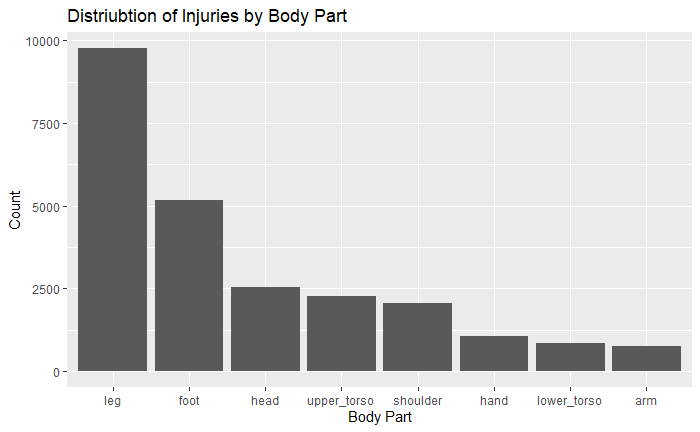

```r
injury_gather %>%
  group_by(bodypart) %>%
  summarise(counts = sum(counts)) %>%
  ggplot(aes(x = reorder(bodypart, -counts), y = counts)) +
  geom_col() +
  xlab("Body Part") +
  ylab("Count") +
  ggtitle("Distriubtion of Injuries by Body Part")
```

Now for the next part at EDA, let’s look at the injury distributions across the various positions in football

```r
levels(as.factor(injuries$position_id))
```

```
[1] ""    "DEF" "K"   "OL"  "P"   "QB"  "RB"  "TE"  "WR"
```

We see we have the following positions: Kicker (K), Offensive Line (OL), Punter (P), Quarter Back (QB), Running Back (RB), Tight End (TE), Wide Reciever (WR) and Defense (DEF).

Since Defense has it’s own category with no specific position (like Linebacker, Defensive Line or Safety), let’s first compare the injury distributions between Offensive Players and Defensive Players

```r
offensive_position <- c("K", "OL", "P", "QB", "RB", "TE", "WR")

offense <- injury_gather %>% filter(position_id %in% offensive_position)
defense <- injury_gather %>% filter(position_id == "DEF")

levels(as.factor(offense$position_id))
```

```
[1] "K"  "OL" "P"  "QB" "RB" "TE" "WR"
```

```r
levels(as.factor(defense$position_id))
```

```
[1] "DEF"
```

```r
dim(offense)
```

```
[1] 61696    29
```

```r
dim(defense)
```

```
[1] 58472    29
```

Overall distribution of offensive injuries

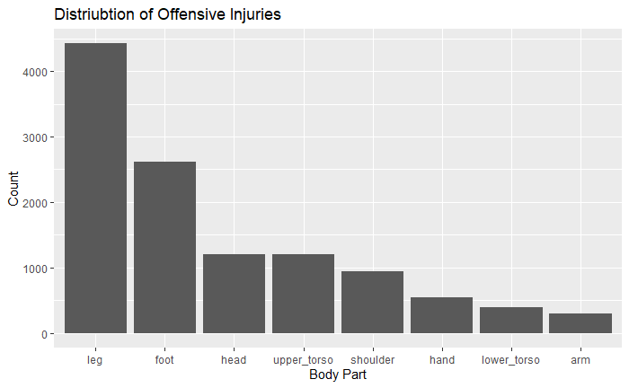

```r
offense %>%
  group_by(bodypart) %>%
  summarise(counts = sum(counts)) %>%
  ggplot(aes(x = reorder(bodypart, -counts), y = counts)) +
  geom_col() +
  xlab("Body Part") +
  ylab("Count") +
  ggtitle("Distriubtion of Offensive Injuries")
```

Overall distribution of defensive injuries

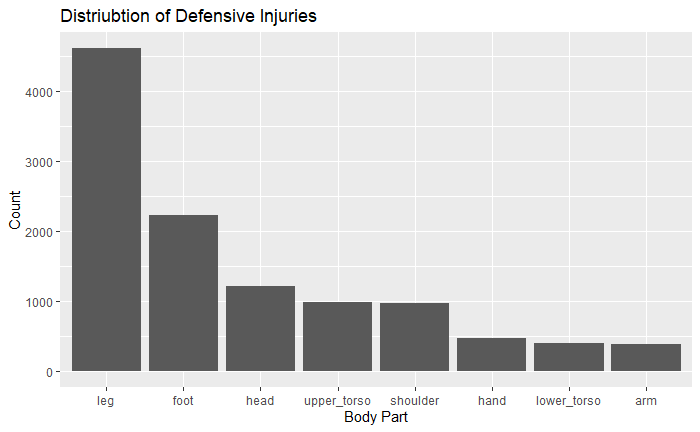

```r
defense %>%
  group_by(bodypart) %>%
  summarise(counts = sum(counts)) %>%
  ggplot(aes(x = reorder(bodypart, -counts), y = counts)) +
  geom_col() +
  xlab("Body Part") +
  ylab("Count") +
  ggtitle("Distriubtion of Defensive Injuries")
```

RSHINY: Dropbox (all injuries, offensive injuries, defensive injuries) Slider (age) ?? min, max

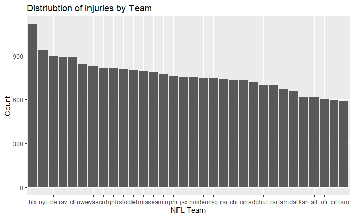

```r
injury_gather %>%
  group_by(team) %>%
  summarise(counts = sum(counts)) %>%
  ggplot(aes(x = reorder(team, -counts), y = counts)) +
  geom_col() +
  xlab("NFL Team") +
  ylab("Count") +
  ggtitle("Distriubtion of Injuries by Team")
```

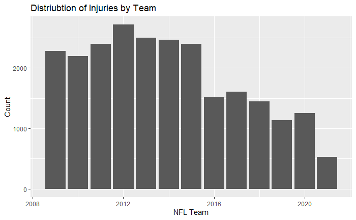

```r
injury_gather %>%
  group_by(year) %>%
  summarise(counts = sum(counts)) %>%
  ggplot(aes(x = year, y = counts)) +
  geom_col() +
  xlab("NFL Team") +
  ylab("Count") +
  ggtitle("Distriubtion of Injuries by Team")
```

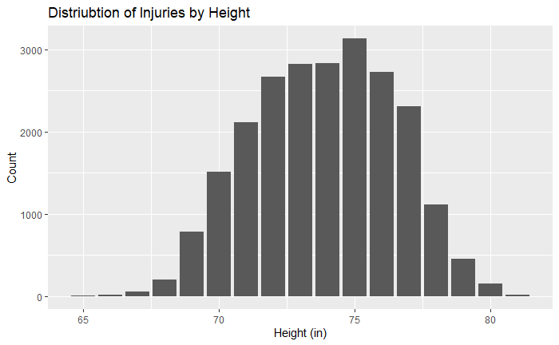

```r
injury_gather %>%
  group_by(height_inches) %>%
  summarise(counts = sum(counts)) %>%
  ggplot(aes(x = height_inches, y = counts)) +
  geom_col() +
  xlab("Height (in)") +
  ylab("Count") +
  ggtitle("Distriubtion of Injuries by Height")
```

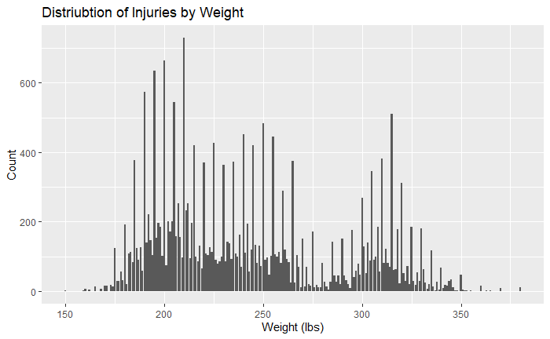

```r
injury_gather %>%
  group_by(weight_pounds) %>%
  summarise(counts = sum(counts)) %>%
  ggplot(aes(x = weight_pounds, y = counts)) +
  geom_col() +
  xlab("Weight (lbs)") +
  ylab("Count") +
  ggtitle("Distriubtion of Injuries by Weight")
```

```r
injury_age <- injury_gather %>% mutate(age = floor(as.numeric(difftime(Sys.Date(),injury_gather$birthdate, units = "weeks"))/52.25))

injury_age
```

| X | name | full_team | team | year | games_in_season | num_games_missing | num_games_injured | injury_types | earliest_injury | latest_injury | position_id | NFL_draft_year | NFL_draft_round | NFL_draft_rank | height_inches | weight_pounds | birthdate | forty_yd | three_cone | bench | broad_jump | combine_height | combine_weight | shuttle | vertical | game_starter | bodypart | counts | age |
| --- | --- | --- | --- | --- | --- | --- | --- | --- | --- | --- | --- | --- | --- | --- | --- | --- | --- | --- | --- | --- | --- | --- | --- | --- | --- | --- | --- | --- | --- |
| 18 | Michael Adams | Arizona Cardinals | crd | 2009 | 18 | 0 | 3 | hamstring | 8 | 14 | DEF | NA | NA | NA | 68 | 178 | 1985-06-17 | NA | NA | NA | NA | NA | NA | NA | NA | 0 | head | 0 | 36 |
| 19 | Jason Banks | Arizona Cardinals | crd | 2009 | 18 | 2 | 2 | ankle | 17 | 18 | DEF | NA | NA | NA | 77 | 300 | 1985-05-08 | NA | NA | NA | NA | NA | NA | NA | NA | 0 | head | 0 | 36 |
| 36 | Bertrand Berry | Arizona Cardinals | crd | 2009 | 18 | 0 | 1 | illness | 13 | 13 | DEF | 1997 | 3 | 86 | 75 | 254 | 1975-08-15 | NA | NA | NA | NA | NA | NA | NA | NA | 0 | head | 0 | 46 |
| 51 | Anquan Boldin | Arizona Cardinals | crd | 2009 | 18 | 3 | 8 | hamstring ankle ankle knee | 1 | 18 | WR | 2003 | 2 | 54 | 73 | 220 | 1980-10-03 | 4.72 | 7.35 | 0 | 114 | 73 | 216 | 4.33 | 33.5 | 1 | head | 0 | 41 |
| 69 | Alan Branch | Arizona Cardinals | crd | 2009 | 18 | 0 | 1 | ankle | 13 | 13 | DEF | 2007 | 2 | 33 | 78 | 350 | 1984-12-29 | 5.07 | 0.00 | 33 | 107 | 78 | 324 | 0.00 | 27.5 | 0 | head | 0 | 36 |
| 86 | Steve Breaston | Arizona Cardinals | crd | 2009 | 18 | 1 | 11 | knee | 1 | 11 | WR | 2007 | 5 | 142 | 73 | 175 | 1983-08-20 | 4.46 | 6.90 | 0 | 124 | 72 | 193 | 4.29 | 33.0 | 1 | head | 0 | 38 |
| 87 | Cody Brown | Arizona Cardinals | crd | 2009 | 18 | 18 | 18 | wrist | 1 | 18 | NA | NA | NA | NA | NA | NA | NA | NA | NA | NA | NA | NA | NA | NA | NA | NA | head | 0 | NA |
| 105 | Levi Brown | Arizona Cardinals | crd | 2009 | 18 | 0 | 2 | ankle knee | 3 | 6 | OL | 2007 | 1 | 5 | 78 | 323 | 1984-03-16 | 5.40 | 7.87 | 31 | 97 | 77 | 323 | 4.89 | 25.5 | 1 | head | 0 | 37 |
| 123 | Calais Campbell | Arizona Cardinals | crd | 2009 | 18 | 0 | 2 | thumb | 17 | 18 | DEF | 2008 | 2 | 50 | 80 | 300 | 1986-09-01 | 5.04 | 7.45 | 16 | 111 | 80 | 290 | 4.69 | 29.5 | 1 | head | 0 | 35 |
| 141 | Karlos Dansby | Arizona Cardinals | crd | 2009 | 18 | 0 | 3 | shoulder | 10 | 12 | DEF | 2004 | 2 | 33 | 76 | 250 | 1981-11-03 | 4.58 | 0.00 | 0 | 0 | 75 | 251 | 0.00 | 0.0 | 1 | head | 0 | 39 |

[output cut: 990 more lines]

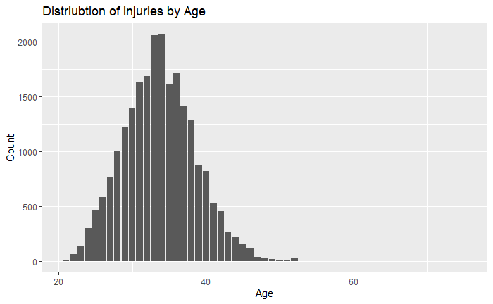

```r
injury_age %>%
  group_by(age) %>%
  summarise(counts = sum(counts)) %>%
  ggplot(aes(x = age, y = counts)) +
  geom_col() +
  xlab("Age") +
  ylab("Count") +
  ggtitle("Distriubtion of Injuries by Age")
```

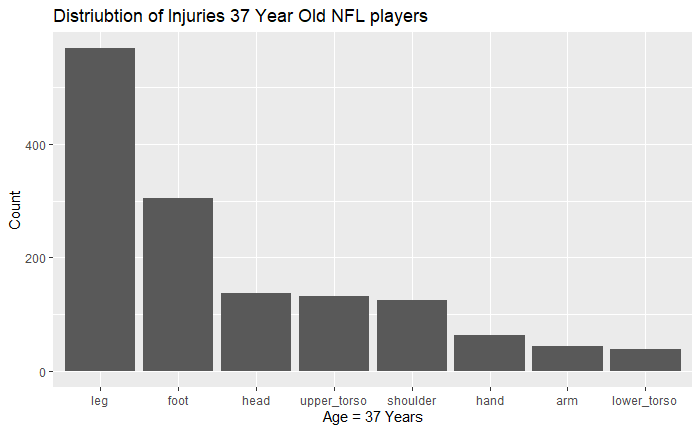

```r
injury_age %>%
  group_by(bodypart) %>%
  filter(age == 37) %>%
  summarise(counts = sum(counts)) %>%
  ggplot(aes(x = reorder(bodypart, - counts), y = counts)) +
  geom_col() +
  xlab("Age = 37 Years") +
  ylab("Count") +
  ggtitle("Distriubtion of Injuries 37 Year Old NFL players")
```